# Contour plot

Autor: José Ángel Martínez Luque

Semestre 1 - 2021

**Titulo** Mortalidad por bajas temperaturas y contaminación en la ciudad de Chicago entre 1997-2000

**Datos**

- *Fuente*: National Morbidity and Mortality Air Pollution Study (NMMAPS)
- *Descripción*: dataset con con 1461 observaciones y 10 variables correspondientes a cada una de las medidas tomadas.
- *Licencia*: Creative Commons Attribution 4.0 International license
- *Fecha publicación*: 2008

**Visualización** etiquetado, titulo, subtitulo, footer, etiquetado informativo de las variables observadas, menu, Contour plot

**Diseño** Se ha identificado por color y etiquetadas cada una de las observaciones seleccionadas para el estudio.

**Preguntas**

¿Hay una relacion entre las muertes en Chicago y las bajas temperaturas < 0ºC?

¿Hay unas relación entre las muertes en Chicago con la contaminación (baja nivel de Ozono) y la temperatura?

**Indicad donde está colgada la visualización y cómo acceder.**

En los siguientes link se puede acceder libremente a la presentación de esta visualización de datos:

- https://jamluque-uoc.github.io/
- https://jamluque-uoc.github.io/html/contour_plot.html

**Definid la técnica de visualización de forma general: nombre, origen, descripción/funcionamiento, ejemplos de aplicación, etc.**

*Contour plot* : observar cómo se relacionan los valores de respuesta ajustados con dos variables continuas, proporciona una vista bidimensional en la que todos los puntos que tienen la misma respuesta se conectan para producir líneas de contorno de las respuestas constantes

- Líneas de contorno que conectan puntos que tienen el mismo valor de respuesta ajustada
- Bandas de contorno de color que representan intervalos de los valores de respuesta ajustada

Una gráfica de contorno puede incluir solo dos variables continuas, cuantitativas, (ejemplo 1 : Mortalidad por Alta temperatura en la ciudad de Chicago)

Se utiliza para representar el cambio en los valores de Z en comparación con los valores de X e Y

Si se quiere tener un valor Z del conjunto de datos se puede hacer (ejemplo 2 : Mortalidad por Contaminación en la ciudad de Chicago)

**Describid el tipo de datos que se representa con esta técnica (datos cuantitativos, cualitativas? Qué estructura tienen que tener para cada técnica?). Explicar las limitaciones en cuanto a datos (hay medida mínima y máxima del juego de datos para esta técnica?).**

- Datos *cuantitativos* pueden ser contados, medidos o expresados utilizando números. Directo y conclusivo
- Datos *cualitativos* son descriptivos y conceptuales. Este tipo de datos puede ser categorizados. Subjetivo, interpretativo y exploratorio

Para este tipo de grafica la base debe ser cuantitativa por los calculos que debe realizar para la representación de la grafica como se ha comentado en un punto mas arriba.

**Hacer una representación con esta técnica de *Contour Plot* usando un conjunto de datos abiertos**

Mas abajo se puede ver una porcion de los datos del dataset usado.

**Comentar brevemente la representaciones indicando qué se representa y qué o qué aspectos muestra o demuestra cada representación.**

*Ejemplo 1: Mortalidad por Alta temperatura en la ciudad de Chicago*

en este ejemplo se representa como es la relación entre las muertes producidas y la temperatura acaecida, se puede observar una relación contra mas temperatura, 18ºC el nivel de muertes no estan alto. Pero si que que observa otro punto alto, 0ºC, temperatura mas baja si que hay mas muertes.

*ejemplo 2 : Mortalidad por Contaminación en la ciudad de Chicago*

Para este ejemplo se ha añadido el valor Z del dataset, “death”, sobre los niveles de ozono y temperatura.

en este punto se puede observar que a menor temeratura, < 0ºC y un nivel de ozono bajo, se registran mas muertes.

```r
library(akima)
library(reshape2)
library(ggplot2)
```

```r
chicago <- read.csv("https://raw.githubusercontent.com/Z3tt/R-Tutorials/master/ggplot2/chicago-nmmaps.csv")
```

```r
head(chicago)
```

```
##   city       date death temp dewpoint      pm10        o3 time season year
## 1 chic 1997-01-01   137 36.0    37.50 13.052268  5.659256 3654 Winter 1997
## 2 chic 1997-01-02   123 45.0    47.25 41.948600  5.525417 3655 Winter 1997
## 3 chic 1997-01-03   127 40.0    38.00 27.041751  6.288548 3656 Winter 1997
## 4 chic 1997-01-04   146 51.5    45.50 25.072573  7.537758 3657 Winter 1997
## 5 chic 1997-01-05   102 27.0    11.25 15.343121 20.760798 3658 Winter 1997
## 6 chic 1997-01-06   127 17.0     5.75  9.364655 14.940874 3659 Winter 1997
```

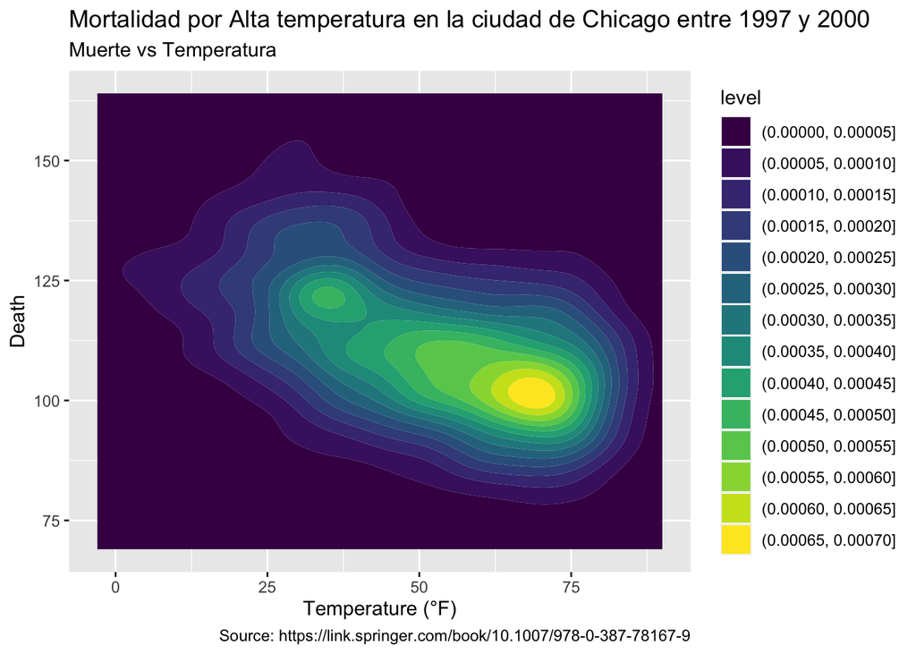

```r
ggplot(chicago, aes(temp, death)) +
  stat_density_2d_filled(show.legend = TRUE) +
  labs(x = "Temperature (°F)", y = "Death",
       title="Mortalidad por Alta temperatura en la ciudad de Chicago entre 1997 y 2000",
       subtitle = "Muerte vs Temperatura",
       caption = "Source: https://link.springer.com/book/10.1007/978-0-387-78167-9")
```

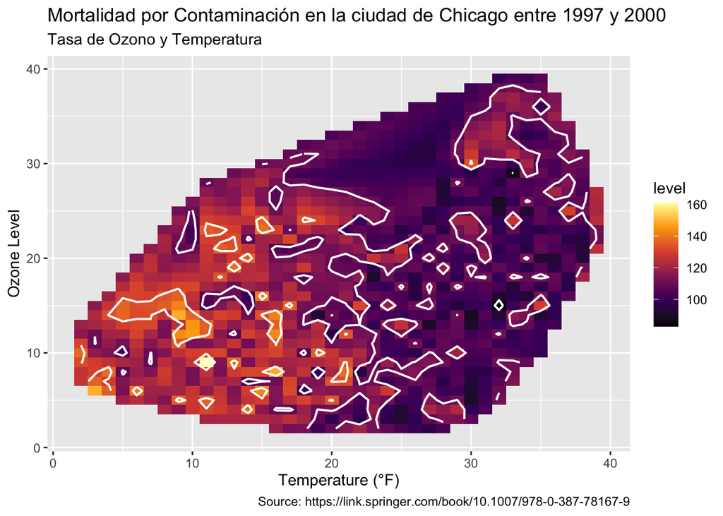

```r
fld <- with(chicago, interp(x = temp, y = o3, z = death))

df <- melt(fld$z, na.rm = TRUE)
names(df) <- c("x", "y", "death")

ggplot(data = df, aes(x = x, y = y, z = death))  +
    stat_contour(aes(fill = ..level..)) +
    geom_tile(aes(fill = death)) +
    stat_contour(color = "white", size = .7, bins = 5) +
    scale_fill_viridis_c(option = "inferno") +
    labs(x = "Temperature (°F)", y = "Ozone Level",
         title="Mortalidad por Contaminación en la ciudad de Chicago entre 1997 y 2000",
         subtitle = "Tasa de Ozono y Temperatura",
         caption = "Source: https://link.springer.com/book/10.1007/978-0-387-78167-9")
```